# Dynamical Divergence Analysis

Maria Laura Marcos, Julian Echave

# Introduction

We study the evolutionary divergence of proteins using the LF-ENM and comparing simulated mutants with experimental data.

We studied the az family. We used the ENM ANM with R0 = 10 to generate mutants. We used as reference for the ENM the protein with pdb code 1bxva. We simulated 10 mutants of this reference for each protein of the family. The az family is of the type beta and consists of the following proteins:

```
 [1] "1rkra" "1jzga" "1nwpa" "1dz0a" "2azaa" "1kdj"  "1m9wa" "1nin"
 [9] "1bawa" "2b3ia" "1plb"  "1ag6"  "1plc"  "1byoa" "1paz"  "1bqk"
[17] "1adwa" "1id2a" "2raca" "1gy1a" "1joi"  "1cuoa" "9pcy"  "7pcy"
[25] "1iuz"  "2plt"  "1pmy"
```

### Dynamical divergence along sites

In this section we consider dynamical divergence along Cartessian coordinates. square.dif.MSF is the square diference between MSF of the proteins relative to the reference protein. We ranked profiles because we found it is the best way to deal with large differences in MSF of divergent sites. We also tried z-normalizing but the results were not good.

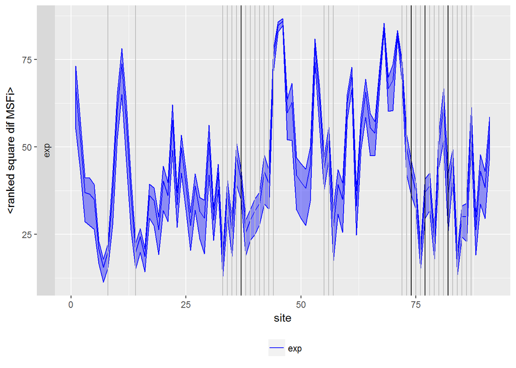

Black lines are the active sites and grey lines are their contacts

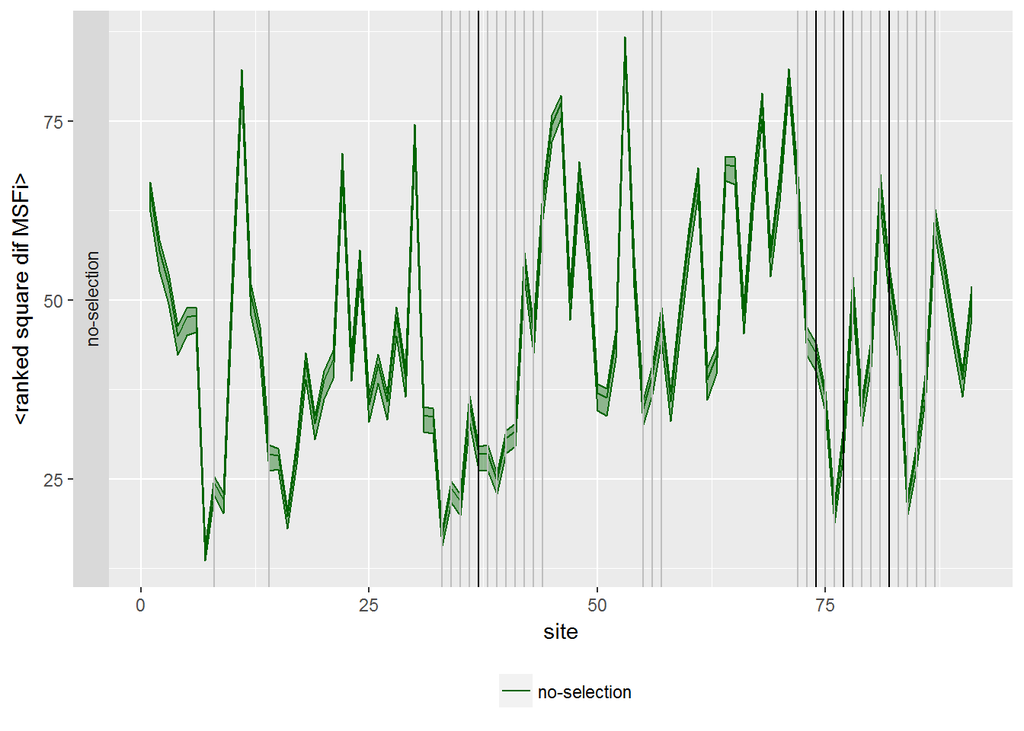

Black lines are the active sites and grey lines are their contacts

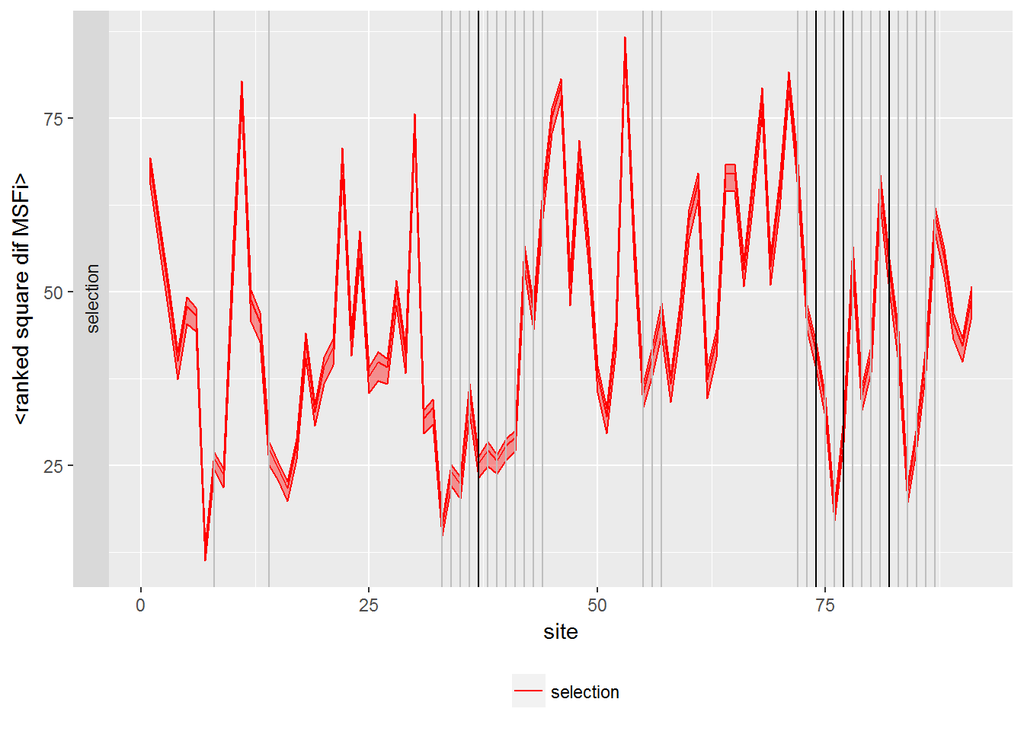

Black lines are the active sites and grey lines are their contacts

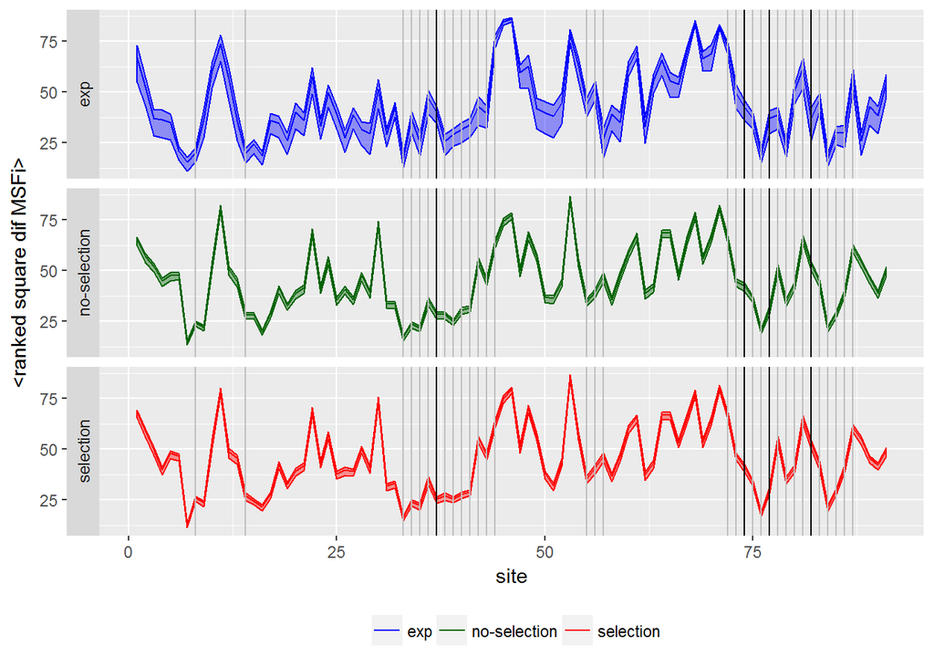

Black lines are the active sites and grey lines are their contacts

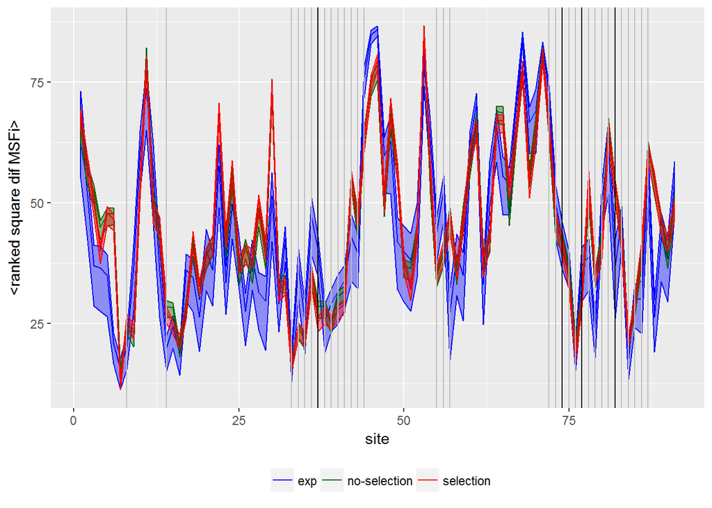

Black lines are the active sites and grey lines are their contacts

| comparison | R |
| --- | --- |
| exp vs no-selection | 0.85 |
| exp vs selection | 0.85 |
| no-selection vs selection | 0.99 |

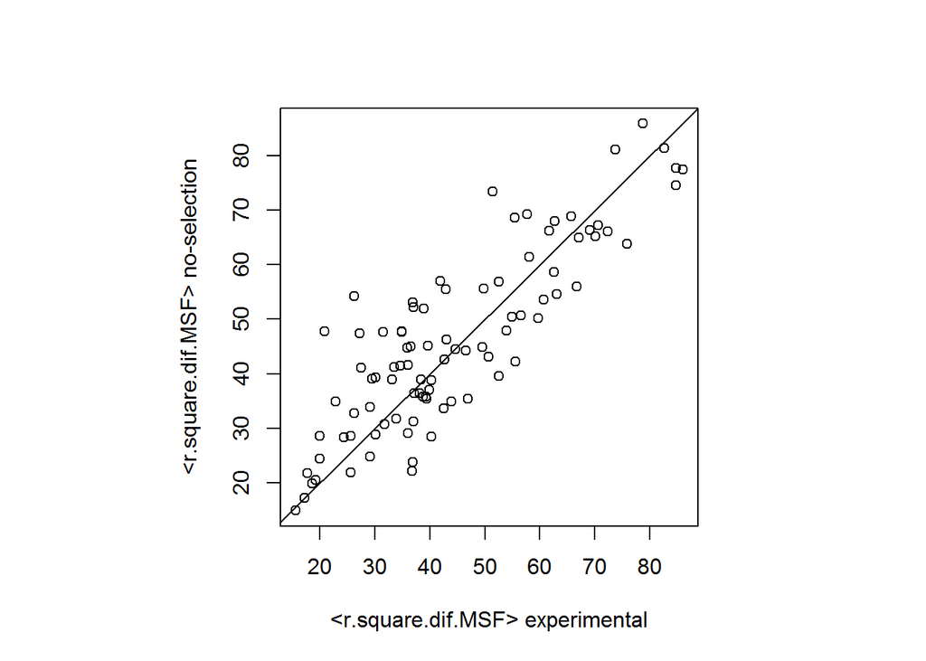

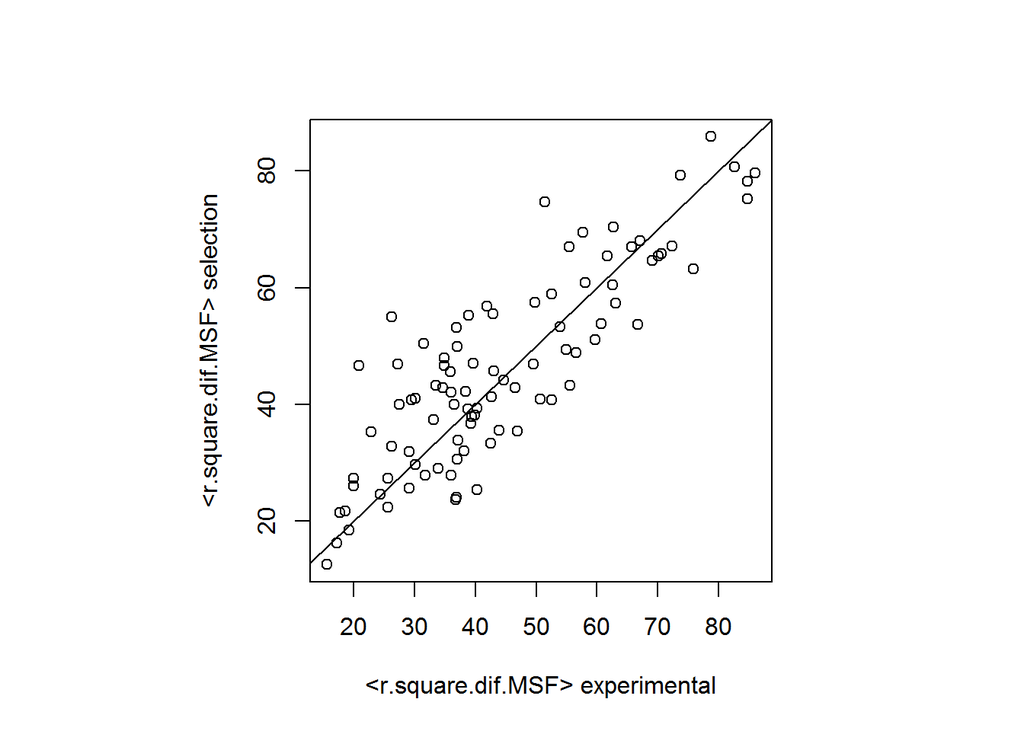

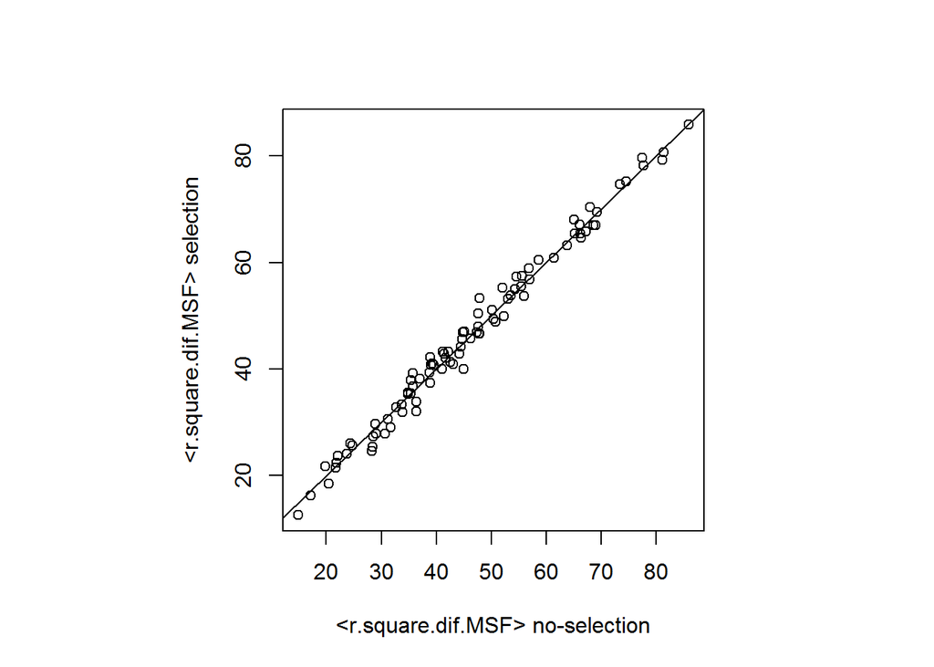

[output not shown]

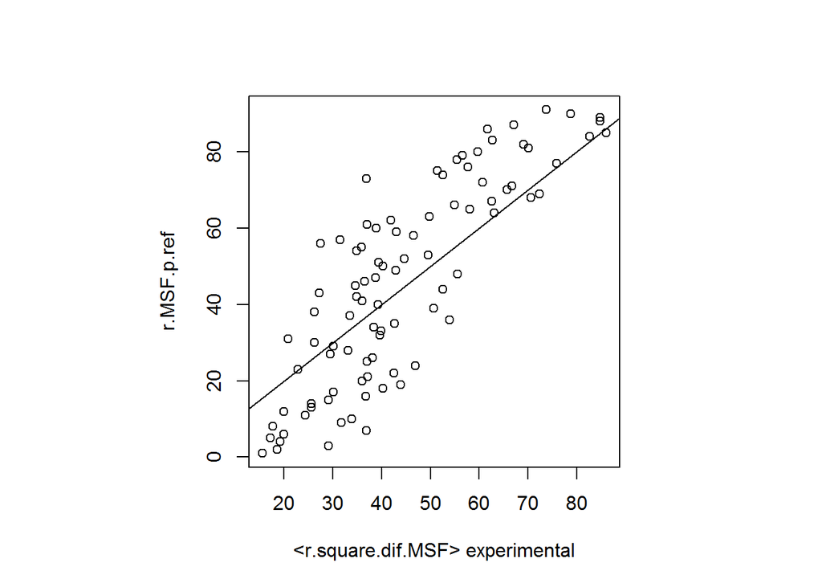

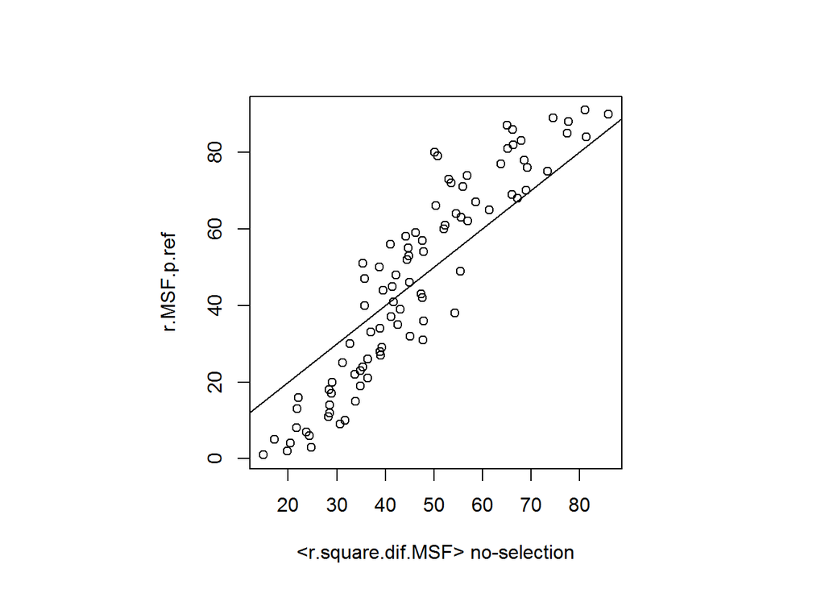

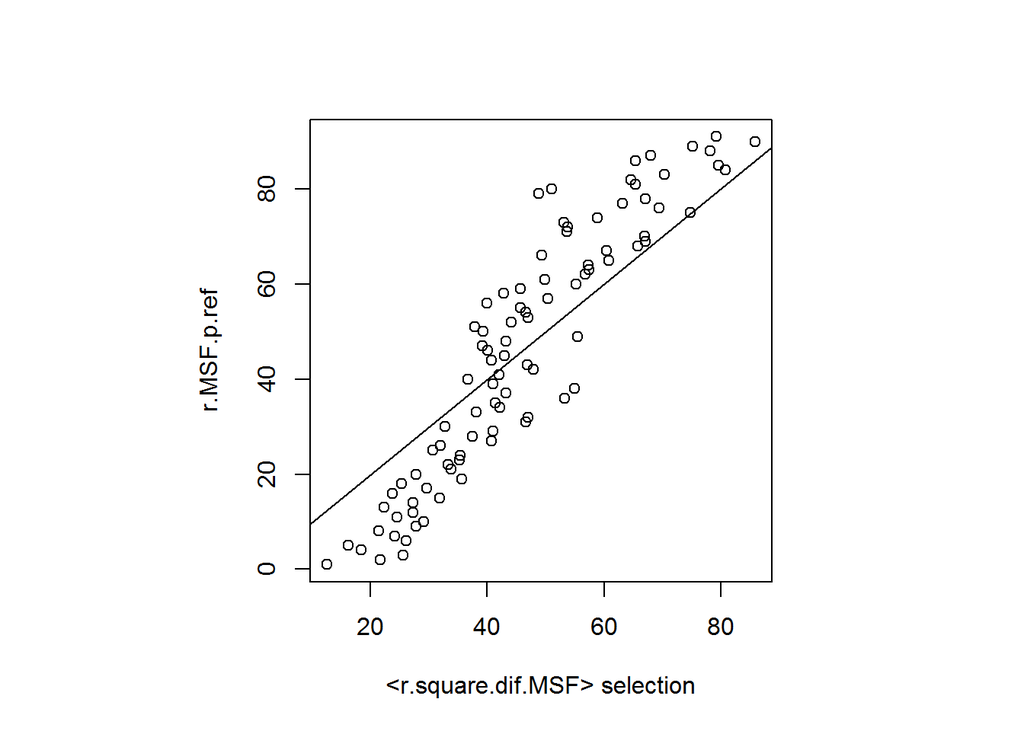

### Comparison structure - dynamics

In this section we compare dri2 profiles (structural variability) with square dif MSF profiles (dynamical variability). To do this, we ranked each profile.

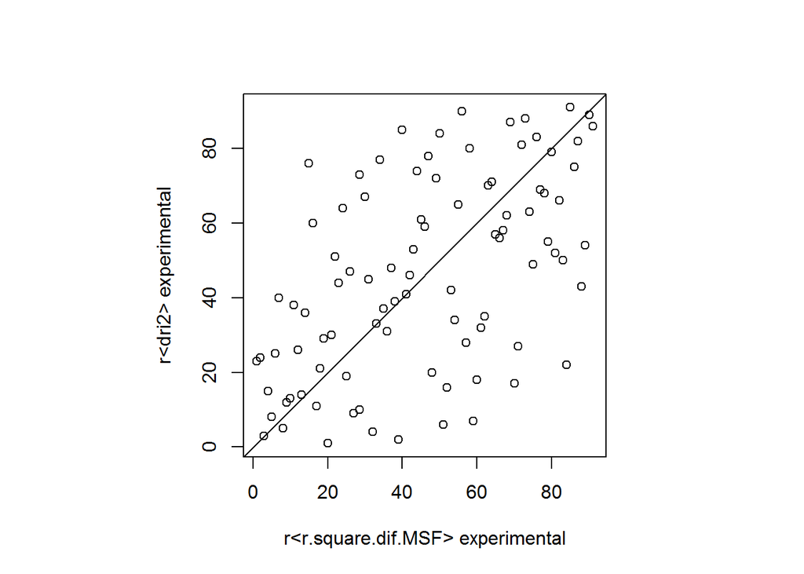

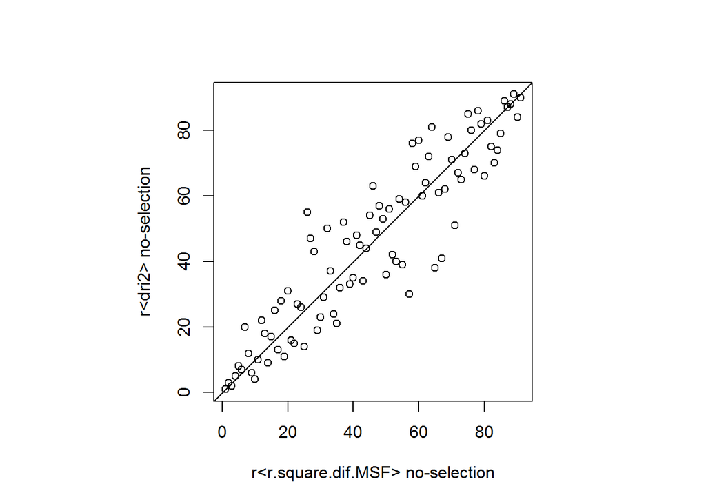

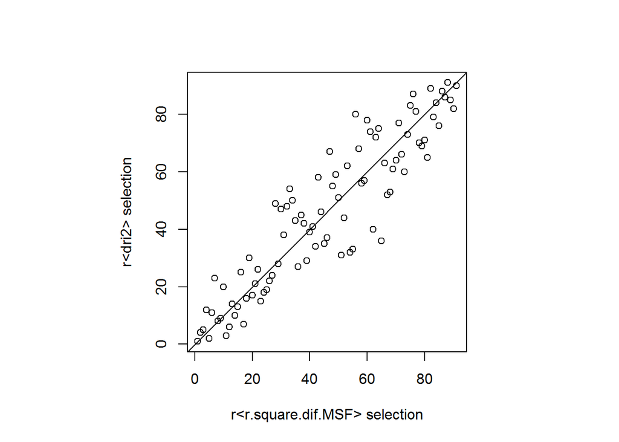

| comparison.structure…dynamics | R |
| --- | --- |
| exp | 0.54 |
| selection | 0.92 |
| no-selection | 0.92 |